# Jupyter Notebook: Heartbeat Classification with RNN, LSTM, and GRU

## Title: Heartbeat Classification using Sequence Models

1. **Dataset Overview:**
   - The dataset contains heartbeat signals derived from two well-known datasets: the MIT-BIH Arrhythmia Dataset and PhysioNet's MIT-BIH Arrhythmia Database.
   - Each row in the dataset is a time series corresponding to one heartbeat, and the signals represent electrocardiogram (ECG) waveforms.
   - The dataset is preprocessed and segmented, with each segment corresponding to a heartbeat. The last column represents the label (5 classes):
     - **'N': 0** - Normal heartbeat
     - **'S': 1** - Supraventricular premature beat
     - **'V': 2** - Premature ventricular contraction
     - **'F': 3** - Fusion of ventricular and normal beat
     - **'Q': 4** - Unclassifiable beat
   - Number of Samples: **109,446**
   - Sampling Frequency: **125 Hz**
   - Training data: `mitbih_train.csv`
   - Testing data: `mitbih_test.csv`
   - Data Source: PhysioNet's MIT-BIH Arrhythmia Dataset

   **Background:**
   - The MIT-BIH Arrhythmia Database includes 48 half-hour excerpts of two-channel ambulatory ECG recordings from 47 subjects, recorded between 1975 and 1979. These recordings were selected to include less common but clinically significant arrhythmias.
   - Each recording was digitized at 360 samples per second per channel, annotated independently by two or more cardiologists.

#### Task 1: Data Exploration

- Load the data and explore its structure.
- Plot a few ECG signals for visualization.
- Check the distribution of classes and identify any imbalance.

#### Task 2: Model Implementation

- Implement three sequence models: RNN, LSTM, and GRU.
- Define the architecture for each model.
- Train each model on the training dataset.

#### Task 3: Performance Evaluation

- Evaluate the performance of each model using:
  - AUC (Area Under the Curve)
  - F1-score
  - Accuracy
- Generate a confusion matrix for each model.
- Plot training and testing loss, AUC, F1-score, and accuracy for each epoch.

#### Task 4: Results Comparison

- Compare the performance of the three models using tables and plots.
- Discuss which model performed the best and why.

#### Task 5: Visualization and Insights

- Visualize key insights such as class-wise performance, confusion matrix heatmaps, and metric trends over epochs.

## Assignments:

```python
import numpy as np
import pandas as pd
import torch
import torch.nn as nn
import torch.optim as optim
from torch.utils.data import Dataset, DataLoader
from sklearn.metrics import roc_auc_score, f1_score, accuracy_score, confusion_matrix
import matplotlib.pyplot as plt
import seaborn as sns
```

```python
# Load the data
def load_data(train_path, test_path):

    # Read the CSV files into pandas DataFrames.
    # header=None means the CSV does not have a header row with column names.
    train_df = pd.read_csv(train_path, header=None)
    test_df  = pd.read_csv(test_path, header=None)

    # Split each DataFrame into:
    # X = all columns except the last one (the 187 time-step signal values)
    # y = the last column (the class label: 0, 1, 2, 3, or 4)
    X_train = train_df.iloc[:, :-1].values
    y_train = train_df.iloc[:, -1].values

    X_test = test_df.iloc[:, :-1].values
    y_test = test_df.iloc[:, -1].values

    # Convert X to float32 because model inputs should be decimal numbers in PyTorch.
    X_train = X_train.astype(np.float32)
    X_test  = X_test.astype(np.float32)

    # Convert y to int64 because CrossEntropyLoss expects integer class labels in PyTorch.
    y_train = y_train.astype(np.int64)
    y_test  = y_test.astype(np.int64)

    # Sanity check: each heartbeat should have 187 time steps (features).
    assert X_train.shape[1] == 187, f"Expected 187 time steps, got {X_train.shape[1]}"
    assert X_test.shape[1] == 187, f"Expected 187 time steps, got {X_test.shape[1]}"

    # Sanity check: labels should only be 0 through 4.
    assert set(np.unique(y_train)).issubset({0, 1, 2, 3, 4}), \
        f"Found unexpected labels in train: {set(np.unique(y_train))}"

    return X_train, y_train, X_test, y_test
```

```python
# Dataset class
class HeartbeatDataset(Dataset):
    def __init__(self, X, y):

        # Save the data inside the Dataset object so DataLoader can use it later.

        # X comes in as a NumPy array with shape (num_examples, 187)
        # We convert it to a Torch tensor so PyTorch can use it.
        # .float() makes sure the numbers are float type (needed for neural networks).
        X_tensor = torch.tensor(X).float()

        # Our sequence models expect input shape (batch, time_steps, input_size).
        # Here, time_steps = 187 and input_size = 1 (one value per time step).
        # So we add a last dimension of size 1 using unsqueeze(-1).
        self.X = X_tensor.unsqueeze(-1)

        # y comes in as labels (0–4). For classification with CrossEntropyLoss,
        # PyTorch expects integer labels of type long (int64).
        self.y = torch.tensor(y).long()

    def __len__(self):
        return len(self.X)

    def __getitem__(self, idx):
        return self.X[idx], self.y[idx]
```

```python
# Data exploration
def explore_data(X_train, y_train):
    # Check data structure
    print("Shape of X_train:", X_train.shape)
    print("Shape of y_train:", y_train.shape)

    # Plot a few ECG signals
    plt.figure(figsize=(12, 6))
    for i in range(5):

        # Want to plot one example heartbeat from each class (0 through 4).
        # The loop variable i will represent the class label.

        # Find all row indices where the label equals i.
        class_indices = np.where(y_train == i)[0]

        # If this class does not appear then this will skip it.
        if len(class_indices) == 0:
            continue

        # Pick the first example from that class.
        idx = class_indices[0]

        # Plot the 187 time steps for that example.
        # X_train[idx] is a 1D array of length 187.
        plt.plot(X_train[idx], label=f"Class {i}")

    plt.title("Sample ECG Signals")
    plt.xlabel("Time Step")
    plt.ylabel("Amplitude")
    plt.legend()
    plt.show()

    # Check class distribution
    class_counts = pd.Series(y_train).value_counts()
    plt.figure(figsize=(8, 6))
    sns.barplot(x=class_counts.index, y=class_counts.values, palette="viridis")
    plt.title("Class Distribution")
    plt.xlabel("Class")
    plt.ylabel("Count")
    plt.show()
```

```python
# RNN Model
class RNNModel(nn.Module):
    def __init__(self, input_size, hidden_size, num_layers, num_classes):
        super(RNNModel, self).__init__()

        # Create an RNN layer that will read the heartbeat sequence from left to right.
        self.rnn = nn.RNN(
            input_size=input_size,
            hidden_size=hidden_size,
            num_layers=num_layers,
            batch_first=True
        )
        # input_size: how many numbers per time step (we have 1 number per time step).
        # hidden_size: how big the RNN "memory" vector is at each time step.
        # num_layers: how many RNN layers are stacked on top of each other.
        # batch_first=True: tells PyTorch our x will look like (batch, time_steps, features).

        # Create a Linear layer that turns the final RNN hidden info into class scores.
        self.fc = nn.Linear(hidden_size, num_classes)
        # nn.Linear(in_features, out_features):
        # in_features = hidden_size because the RNN outputs a vector of length hidden_size.
        # out_features = num_classes because we want one score per class (5 total).

    def forward(self, x):

        # Send the input sequence through the RNN layer.
        rnn_out, h_n = self.rnn(x)
        # x: the input batch, shape (batch_size, 187, 1).
        # rnn_out: the output at EVERY time step, shape (batch_size, 187, hidden_size).
        # h_n: the final hidden state for each layer, shape (num_layers, batch_size, hidden_size).

        # Grab the RNN output from the LAST time step (this summarizes the whole sequence).
        last_time_step = rnn_out[:, -1, :]
        # rnn_out[:, -1, :]:
        # ":" means "all examples in the batch"
        # "-1" means "the last time step"
        # ":" means "all hidden units"

        # Turn that last hidden representation into class scores (logits).
        out = self.fc(last_time_step)
        # out: shape (batch_size, num_classes).
        # These are raw scores (logits), not probabilities.

        return out
```

```python
# LSTM Model
class LSTMModel(nn.Module):
    def __init__(self, input_size, hidden_size, num_layers, num_classes):
        super(LSTMModel, self).__init__()

        # LSTM is like an RNN but it has gates that help it remember information better.
        # RNNs are better for short sequences, but encounter vanishing gradients and cannot recall tokens from early in long sequences
        # Create an LSTM layer (an RNN type that is better at remembering long patterns).
        self.lstm = nn.LSTM(
            input_size=input_size,
            hidden_size=hidden_size,
            num_layers=num_layers,
            batch_first=True
        )
        # input_size: number of features at each time step (we use 1).
        # hidden_size: size of the hidden state vector the LSTM keeps.
        # num_layers: number of stacked LSTM layers.
        # batch_first=True: input shape will be (batch, time_steps, features).

        # Create a Linear layer to convert the LSTM output into class scores.
        self.fc = nn.Linear(hidden_size, num_classes)
        # hidden_size -> num_classes:
        # We take the last time step output (length hidden_size) and map it to 5 scores.

    def forward(self, x):
        ####START CODE HERE

        # Pass the input sequence through the LSTM.
        lstm_out, (h_n, c_n) = self.lstm(x)
        # x: shape (batch_size, 187, 1)
        # lstm_out: output at every time step, shape (batch_size, 187, hidden_size)
        # h_n: final hidden states for each layer, shape (num_layers, batch_size, hidden_size)
        # c_n: final cell states for each layer, shape (num_layers, batch_size, hidden_size)
        # (The cell state is a special "memory" LSTM keeps internally.)

        # Take the output from the last time step to represent the whole sequence.
        last_time_step = lstm_out[:, -1, :]
        # lstm_out[:, -1, :] means all examples, last time step, all hidden features

        # Convert that last step into class scores.
        out = self.fc(last_time_step)
        # out: shape (batch_size, num_classes)
        # These are scores used for cross entropy loss.

        return out
```

```python
# GRU Model
class GRUModel(nn.Module):
    def __init__(self, input_size, hidden_size, num_layers, num_classes):
        super(GRUModel, self).__init__()

        # Create a GRU layer (similar to LSTM but a bit simpler/faster).
        # Both LSTMs and GRU are intended to solve the issue of the vanishing gradient in RNNs.
        # However, they are different in that LSTMs have three gates (input, forget, output) and separate cell states.
        # GRUs only have two gates and no separate cell states.
        self.gru = nn.GRU(
            input_size=input_size,
            hidden_size=hidden_size,
            num_layers=num_layers,
            batch_first=True
        )
        # input_size: features per time step (1 in this dataset)
        # hidden_size: size of GRU hidden state (how much it can "remember")
        # num_layers: stacked GRU layers
        # batch_first=True: input x has shape (batch, time_steps, features)

        # Create a Linear layer to convert the GRU hidden output into class scores.
        self.fc = nn.Linear(hidden_size, num_classes)
        # This maps a vector of length hidden_size into 5 class scores.

    def forward(self, x):

        # Pass the input sequence through the GRU.
        gru_out, h_n = self.gru(x)
        # x: shape (batch_size, 187, 1)
        # gru_out: output at every time step, shape (batch_size, 187, hidden_size)
        # h_n: final hidden state for each layer, shape (num_layers, batch_size, hidden_size)

        # Take the GRU output from the last time step to summarize the whole sequence.
        last_time_step = gru_out[:, -1, :]
        # gru_out[:, -1, :]:
        # ":" = all examples in the batch
        # "-1" = last time step (time step 187)
        # ":" = all hidden units

        # Convert the last time step hidden vector into class scores (logits).
        out = self.fc(last_time_step)
        # out: shape (batch_size, num_classes)
        # logits = raw scores, CrossEntropyLoss will handle softmax internally.

        return out
```

```python
# Training and evaluation functions
def train_model(model, criterion, optimizer, train_loader, device):
    model.train()
    total_loss = 0
    all_preds = []
    all_targets = []
    for X, y in train_loader:

        # Move the input batch X to the same device as the model (CPU or GPU).
        X = X.to(device)
        # X: a batch of heartbeat sequences (a Tensor).
        # device: tells PyTorch where to do the work ("cpu" or "cuda").

        # Move the labels y to the same device as the model (CPU or GPU).
        y = y.to(device)
        # y: the true class labels for this batch (0–4).
        # We move y so the loss calculation happens on the same device as outputs.

        # Clear old gradients so they do not build up across batches.
        optimizer.zero_grad()
        # optimizer: the thing that updates the model weights (ex: Adam).
        # zero_grad(): resets gradients from the previous iteration.

        # Run the model on X to get output scores for each class (logits).
        outputs = model(X)
        # model(X): runs the forward pass.
        # outputs: shape (batch_size, num_classes), raw scores for each class.

        # Compute the loss (how wrong the model is on this batch).
        loss = criterion(outputs, y)
        # criterion: the loss function (CrossEntropyLoss).
        # loss: a single number (Tensor) measuring error for this batch.

        # Compute gradients of the loss with respect to all model parameters.
        loss.backward()
        # backward(): calculates gradients and stores them in each parameter’s .grad.

        # Update the model weights using the gradients we just computed.
        optimizer.step()
        # step(): applies the optimizer rule to change weights and reduce future loss.

        # Add this batch’s loss value to the running total loss.
        total_loss += loss.item()
        # loss.item(): converts the Tensor loss into a normal Python float.

        # Convert the output scores into predicted class labels.
        preds = torch.argmax(outputs, dim=1)
        # torch.argmax(..., dim=1): picks the class with the biggest score for each row.
        # preds: a Tensor of predicted class IDs, shape (batch_size,).

        # Add the predictions to our list (we move to CPU first so NumPy/sklearn can use it).
        all_preds.extend(preds.cpu().numpy())
        # preds.cpu(): moves predictions to CPU memory.
        # .numpy(): converts Tensor -> NumPy array.
        # extend(...): adds all elements to the Python list.

        # Add the true labels to our list (also moved to CPU for sklearn).
        all_targets.extend(y.cpu().numpy())
        # y.cpu().numpy(): converts labels to a NumPy array on CPU.

        total_loss += loss.item()

        preds = torch.argmax(outputs, dim=1)
        all_preds.extend(preds.cpu().numpy())
        all_targets.extend(y.cpu().numpy())

    auc = roc_auc_score(pd.get_dummies(all_targets), pd.get_dummies(all_preds), multi_class='ovr')
    f1 = f1_score(all_targets, all_preds, average='weighted')
    acc = accuracy_score(all_targets, all_preds)
    return total_loss / len(train_loader), auc, f1, acc


def evaluate_model(model, criterion, data_loader, device):
    model.eval()
    total_loss = 0
    all_preds = []
    all_targets = []
    with torch.no_grad():
        for X, y in data_loader:

            # Move the input batch X to the same device as the model (CPU or GPU).
            X = X.to(device)
            # X: a batch of heartbeat sequences (a Tensor).
            # device: tells PyTorch where to do the work ("cpu" or "cuda").

            # Move the labels y to the same device as the model (CPU or GPU).
            y = y.to(device)
            # y: the true class labels for this batch (0–4).

            # Run the model on X to get output scores for each class (logits).
            outputs = model(X)
            # outputs: shape (batch_size, num_classes), raw scores for each class.

            # Compute the loss for this batch.
            loss = criterion(outputs, y)
            # loss: a single number (Tensor) measuring error for this batch.

            # Add this batch's loss to the running total loss.
            total_loss += loss.item()
            # loss.item(): converts the Tensor loss into a normal Python float.

            # Convert the output scores into predicted class labels.
            preds = torch.argmax(outputs, dim=1)
            # preds: predicted class IDs, shape (batch_size,).

            # Save predictions to a list (move to CPU so NumPy/sklearn can use them).
            all_preds.extend(preds.cpu().numpy())
            # all_preds: a Python list of predictions across all batches.

            # Save true labels to a list (move to CPU so NumPy/sklearn can use them).
            all_targets.extend(y.cpu().numpy())
            # all_targets: a Python list of true labels across all batches.

    auc = roc_auc_score(pd.get_dummies(all_targets), pd.get_dummies(all_preds), multi_class='ovr')
    f1 = f1_score(all_targets, all_preds, average='weighted')
    acc = accuracy_score(all_targets, all_preds)
    return total_loss / len(data_loader), auc, f1, acc

def plot_metrics(train_metrics, test_metrics, epochs):
    plt.figure(figsize=(12, 6))
    for metric_name in train_metrics.keys():
        plt.plot(range(epochs), train_metrics[metric_name], label=f"Train {metric_name}")
        plt.plot(range(epochs), test_metrics[metric_name], label=f"Test {metric_name}", linestyle="--")
    plt.xlabel("Epoch")
    plt.ylabel("Value")
    plt.legend()
    plt.show()
```

### Begin analysis

```python
train_path = "mitbih_train.csv"
test_path = "mitbih_test.csv"

# Load data
X_train, y_train, X_test, y_test = load_data(train_path, test_path)
```

```
Shape of X_train: (87554, 187)
Shape of y_train: (87554,)
```

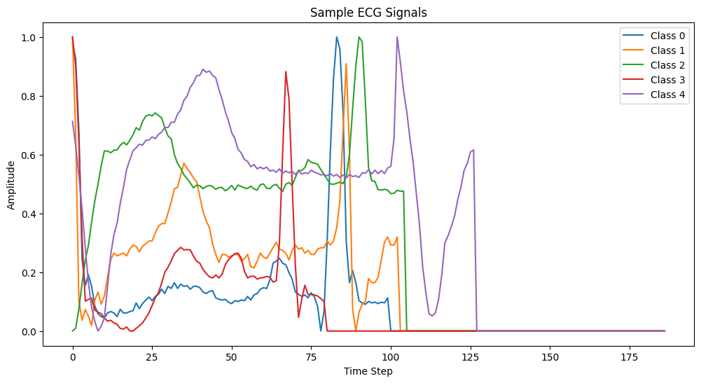

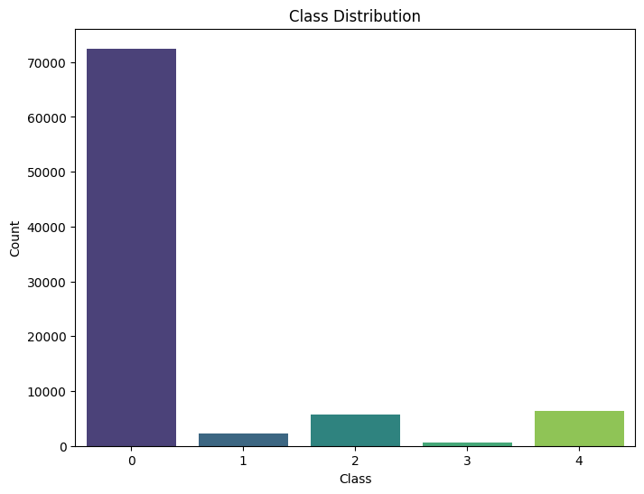

```python
# Explore data
explore_data(X_train, y_train)
```

```
Training RNN...
```

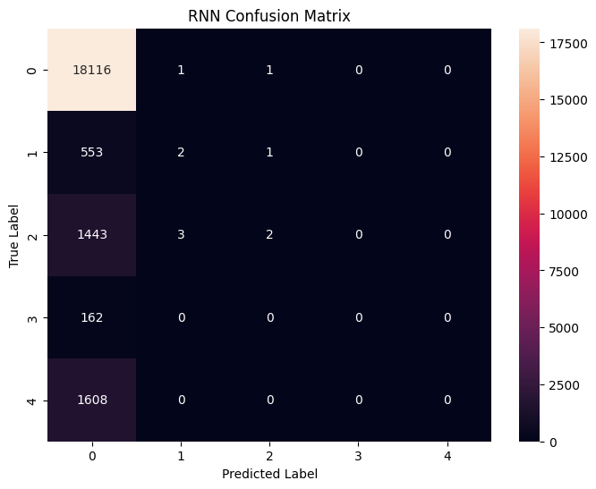

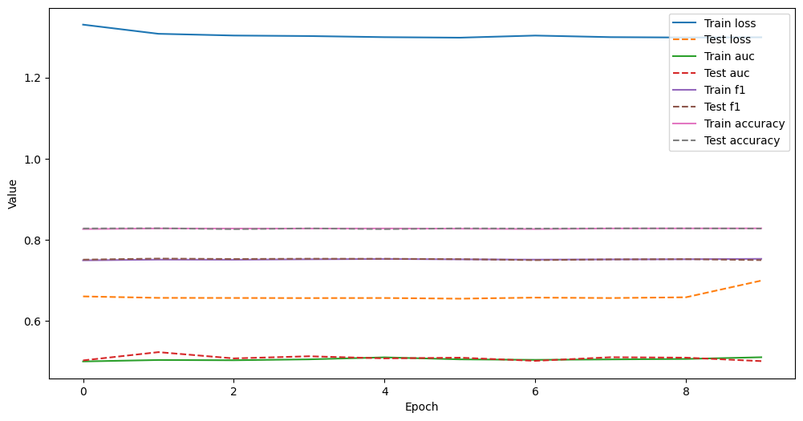

```
Training LSTM...
```

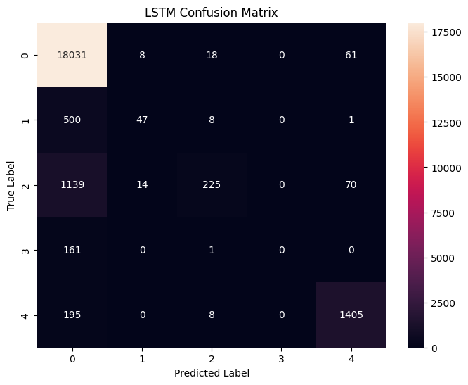

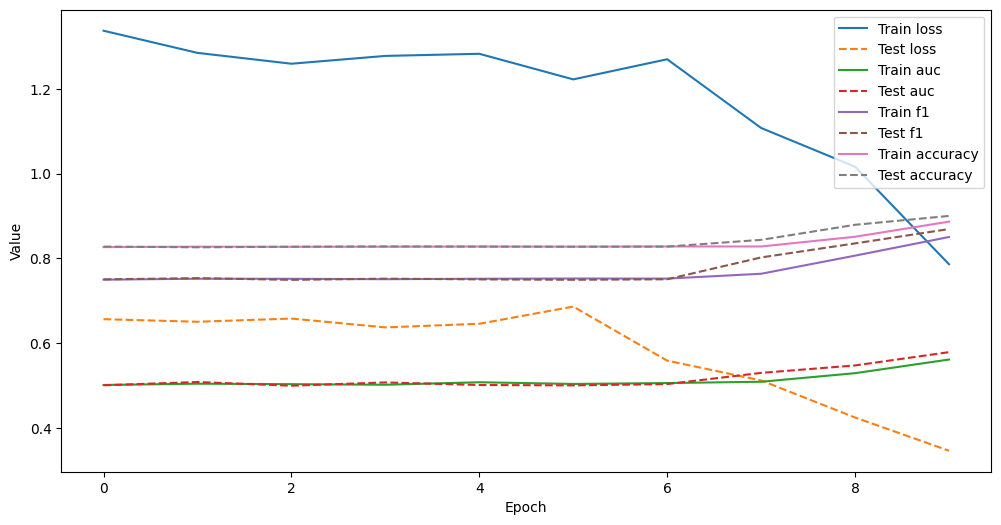

```
Training GRU...
```

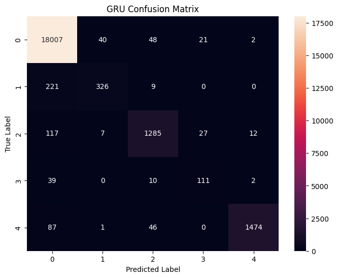

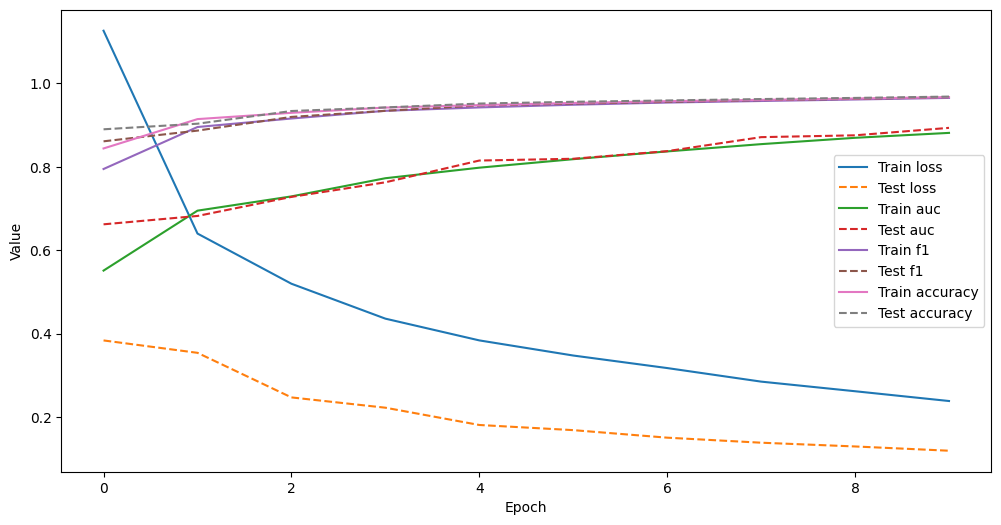

```python
train_dataset = HeartbeatDataset(X_train, y_train)
test_dataset = HeartbeatDataset(X_test, y_test)
train_loader = DataLoader(train_dataset, batch_size=64, shuffle=True)
test_loader = DataLoader(test_dataset, batch_size=64, shuffle=False)

# Last time I trained a model, the training process was interrupted and the kernel was corrupted.
# To prevent that from happening, I am importing os
# This will let me create folders and check if checkpoint files exist.
import os
# os is a built-in Python module for working with files/folders.

# input_size is number of features per time step in the sequence.
input_size = 1
# Set input_size to 1 because each time step has exactly 1 feature value.

# hidden_size is how many hidden units (memory size) the recurrent layer uses.
hidden_size = 64
# Set hidden_size to 64 (common starting size for RNN/LSTM/GRU models according to online sources).

# num_layers is how many recurrent layers are stacked.
num_layers = 1
# Set num_layers to 1 to start with a simple single-layer recurrent model.

# num_classes is number of output classes.
num_classes = 5
# Set num_classes to 5 because labels are 0,1,2,3,4 (five classes).

# num_epochs is how many full passes through the training data.
num_epochs = 10
# Setting epochs to 10 based on advice from online and classmates.

# Choose GPU if available; otherwise use CPU.
device = torch.device("cuda" if torch.cuda.is_available() else "cpu")
# torch.device(...): tells PyTorch where to run computations.
# "cuda" means GPU, "cpu" means normal processor.

models = {
    "RNN": RNNModel(input_size, hidden_size, num_layers, num_classes).to(device),
    "LSTM": LSTMModel(input_size, hidden_size, num_layers, num_classes).to(device),
    "GRU": GRUModel(input_size, hidden_size, num_layers, num_classes).to(device)
}

criterion = nn.CrossEntropyLoss()
results = {}

for model_name, model in models.items():
    print(f"Training {model_name}...")
    optimizer = optim.Adam(model.parameters(), lr=0.001)

    train_metrics = {"loss": [], "auc": [], "f1": [], "accuracy": []}
    test_metrics = {"loss": [], "auc": [], "f1": [], "accuracy": []}

    for epoch in range(num_epochs):
        train_loss, train_auc, train_f1, train_acc = train_model(model, criterion, optimizer, train_loader, device)
        train_metrics["loss"].append(train_loss)
        train_metrics["auc"].append(train_auc)
        train_metrics["f1"].append(train_f1)
        train_metrics["accuracy"].append(train_acc)

        test_loss, test_auc, test_f1, test_acc = evaluate_model(model, criterion, test_loader, device)
        test_metrics["loss"].append(test_loss)
        test_metrics["auc"].append(test_auc)
        test_metrics["f1"].append(test_f1)
        test_metrics["accuracy"].append(test_acc)

        print(f"Epoch {epoch + 1}/{num_epochs}: Train Loss: {train_loss:.4f}, Test Loss: {test_loss:.4f}, Test AUC: {test_auc:.4f}, Test F1: {test_f1:.4f}, Test Acc: {test_acc:.4f}")

    results[model_name] = (train_metrics, test_metrics)

    # Confusion Matrix
    y_true = []
    y_pred = []
    with torch.no_grad():
        for X, y in test_loader:
            X, y = X.to(device), y.to(device)
            outputs = model(X)
            preds = torch.argmax(outputs, dim=1)
            y_true.extend(y.cpu().numpy())
            y_pred.extend(preds.cpu().numpy())

    # Create the confusion matrix from true labels and predicted labels.
    cm = confusion_matrix(y_true, y_pred)
    # cm: a 5x5 table where rows are true classes and columns are predicted classes.

    plt.figure(figsize=(8, 6))

    # Make a heatmap so the confusion matrix is easy to read.
    sns.heatmap(cm, annot=True, fmt="d", xticklabels=[0, 1, 2, 3, 4], yticklabels=[0, 1, 2, 3, 4])
    # sns.heatmap(...): draws a colored grid.
    # annot=True: shows the numbers inside each cell.
    # fmt="d": format numbers as integers.
    # xticklabels/yticklabels: label the axes with class IDs.

    # Label the x-axis so we know these are the model’s predicted classes.
    plt.xlabel("Predicted Label")
    # Predicted Label: what the model guessed.

    # Label the y-axis so we know these are the true classes.
    plt.ylabel("True Label")
    # True Label: the correct answer from the dataset.

    # Add a title so we know which model this confusion matrix is for.
    plt.title(f"{model_name} Confusion Matrix")
    # model_name: "RNN", "LSTM", or "GRU".

    plot_metrics(train_metrics, test_metrics, num_epochs)
```

[output not shown]

```python
#########################
# Discussion of Findings
#########################
#
# Three different sequence models were trained (basic RNN, LSTM, and GRU) to classify heartbeat signals. Each heartbeat is a
# sequence of 187 time steps, and the goal was to predict one of 5 classes (0-4). I mostly wanted to see which type of recurrent
# model handled the sequence the best. To interpret this, I compared metrics such as training loss (cross entropy loss which
# punishes the model when it gives low score/probability to the correct class), test accuracy (what percent of heartbeats were
# classified correctly), F1 (how often the model is right when it predicts a class and how many of the real examples for a class
# the model caught), and AUC (how well the model separates classes across thresholds). I also looked at the confusion matrix outputs
# from running each sequence model, which displays a table that shows what the model predicted vs. what the true class was.
#
# The plain RNN didn't improve much. Across the 10 epochs I set the training to, the test accuracy basically stayed the same
# (around 0.827) and so did the loss (train loss around 1.3 for most epochs). By the end, the RNN's test accuracy was 0.8277,
# test F1 was 0.7500, and test AUC was 0.5011. Basic RNNs can have trouble remembering information from early in long sequences,
# so it makes sense that it got stuck and didn't learn a lot.
#
# The LSTM did better than the basic RNN. Even though it looked rough at the beginning of training, it drastically improved
# by the 10th epoch. For example, around epochs 6-10 the test loss dropped a lot (from around 0.6865 in epoch 6 to around 0.3468
# in epoch 10). At the same time, the accuracy jumped a lot as well (form around 0.8277 to 0.9002). By epoch 10, the test accuracy
# reached 0.9002, F1 reached 0.8693, and AUC reached 0.5791. The three gates in the LSTM help it learn more meaningful
# patterns compared to the basic RNN.
#
# The GRU sequence model was clearly the best model from my results. It steadily improved over all the epochs and ended with the
# strongest performance (test loss 0.1194, test accuracy 0.9685, F1 0.9671, and AUC 0.8936). Also, the confusion matrix for the
# GRU looked the cleanest with a stronger diagonal and fewer mistakes overall (whereas the other two sequence model types had more
# off-diagonal errors).
#
# Overall, based on the metrics and the confusion matrices, my results show GRU > LSTM > RNN for this data set. The big takeaway
# is that the gated models (LSTM and GRU) handle sequence classification much better than a basic RNN here since we are dealing
# with a long sequence.
```